# HRTC Poster Figures

Hunter Ratliff, @HunterRatliff1

2/16/2019

If you’d like the source *data*, reach out to the [BHAR](https://www.utmb.edu/bhar/about-us/bhar-team) office or DM me on [Twitter](https://twitter.com/HunterRatliff1)

# Bar chart

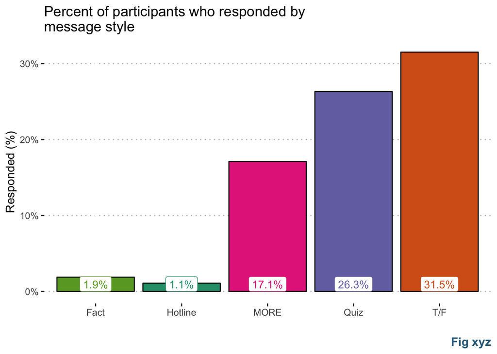

```r
HRTC %>%
  mutate(Replied = as.character(Replied)) %>%
  mutate(
    Replied = recode(Replied, "0"="No"),
    Replied = recode(Replied, "1"="Yes")
    ) %>%
  count(campg.day, Type, Replied) %>%
  spread(Replied, n) %>%
  group_by(Type) %>%
  summarise(Yes = sum(Yes, na.rm=T), No=sum(No, na.rm=T)) %>%
  mutate(
    `Reply %` = Yes/(Yes+No),
    n         = Yes + No
  ) %>%
  rename(Style=Type) %>%

  ggplot(aes(x=Style, y=`Reply %`, fill=Style)) +
  geom_col(color="black") +
  geom_label(aes(y=0, label=percent(`Reply %`), color=Style), fill="white", vjust=0) +
  scale_fill_manual(values=color_guide, guide=F) +
  scale_color_manual(values=color_guide, guide=F) +
  theme_pubclean() + theme(
    plot.subtitle  = element_text(face="italic", color="#A1A1A1", size=rel(0.9)),
    plot.caption   = element_text(face="bold", color="#2d6987", size=rel(1))
  ) +
  labs(x="", y="Responded (%)", caption = "Fig xyz",
       title="Percent of participants who responded by\nmessage style") +
  scale_y_continuous(labels=percent)
```

# Graphically represent model

## Coeffs

```r
df <- HRTC %>%
  filter(userResponses>0) %>%
  # filter(Type!="Fact", Type!="Hotline") %>%
  mutate(Category = as.factor(Category)) %>%
  mutate(Replied = ifelse(Replied==1, "Yes", "No")) %>%
  mutate(Replied = factor(Replied, levels=c("No","Yes")))


mod <- glm(Replied ~ Type + grade + race + gender + userResponses + campg.num,
           data=df, family=binomial(link = "logit"))


# HRTC %>% group_by(Type, BaseMsg, ReplyMsg) %>%
#   summarise(
#     Received = n(),
#     Replied = sum(Replied, na.rm = T),
#     Replied_percent = round(100*sum(Replied, na.rm = T)/n())
#   ) %>%
#   arrange(Type, Received) %>%
#   readr::write_excel_csv("~/Downloads/Message Types.csv")
```

```r
# Save df with B (estimate) & CIs (and their exp values)
x <- cbind(broom::tidy(mod), broom::confint_tidy(mod)) %>%
  rename(B=estimate, LL=conf.low, UL=conf.high) %>%
  mutate(expB=exp(B), expLL=exp(LL), expUL=exp(UL)) %>%
  mutate(
    VarCat = "",
    VarCat = ifelse(str_detect(term, "Type"), "Style", VarCat),
    term   = str_replace(term, "Type", ""),
    VarCat = ifelse(str_detect(term, "gender"), "Gender", VarCat),
    term   = str_replace(term, "gender", ""),
    VarCat = ifelse(str_detect(term, "race"), "Race", VarCat),
    term   = str_replace(term, "race", ""),
    VarCat = ifelse(str_detect(term, "grade"), "Grade", VarCat),
    term   = str_replace(term, "grade", ""),
    term   = ifelse(VarCat=="Grade", str_c(term, "th"), term),
    term   = ifelse(term=="Other", str_c(term, VarCat, sep=" "), term)
  ) %>%
  dplyr::select(term, VarCat, B, LL, UL, expB, expLL, expUL, everything())
```

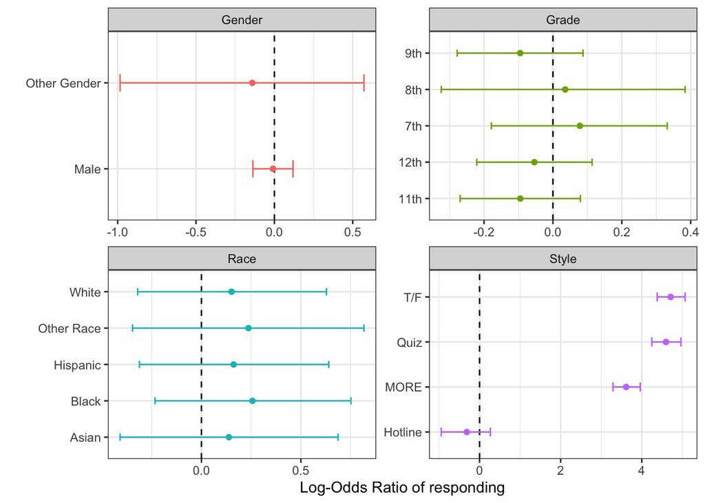

```r
x %>% filter(VarCat!="") %>%

  ggplot(aes(x=term, y=B, color=VarCat)) +
  geom_hline(yintercept = 0, linetype = 2) +
  geom_point() +
  geom_errorbar(aes(ymin=LL, ymax=UL), width=.2) +
  coord_flip() + guides(color=F) + theme_bw() +
  labs(x="", y="Log-Odds Ratio of responding") +
  facet_wrap("VarCat", scales="free")
```

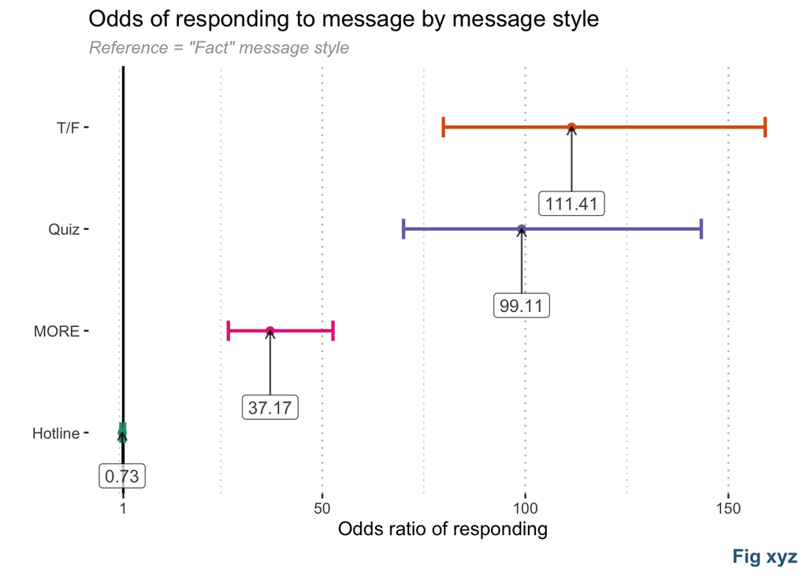

```r
x %>% filter(VarCat!="") %>%
  filter(VarCat=="Style") %>%

  ggplot(aes(x=term, y=expB, color=term)) +
  geom_hline(yintercept = 1, linetype = 1, alpha=1, size=0.75) +
  geom_point(size=2) +
  geom_errorbar(aes(ymin=expLL, ymax=expUL), width=.2, size=1) +
  geom_label_repel(aes(label=round(expB,2)), nudge_x=-0.75, alpha=0.75,
                   arrow = arrow(length = unit(0.02, "npc")), color="black") +


  scale_color_manual(values=color_guide) +
  scale_y_continuous(breaks=c(1,50,100, 150), minor_breaks = c(0,25,75,125)) +
  coord_flip() + guides(color=F) + theme_pubclean(flip=T) +
  theme(panel.grid.minor.x = element_line(linetype = "dotted",
                                          color = "grey"),
        plot.caption       = element_text(face="bold", color="#2d6987", size=rel(1)),
        plot.subtitle      = element_text(face="italic", color="#A1A1A1", size=rel(0.9))) +
  labs(x="", y="Odds ratio of responding", title="Odds of responding to message by message style",
       subtitle='Reference = "Fact" message style', caption = 'Fig xyz')
```

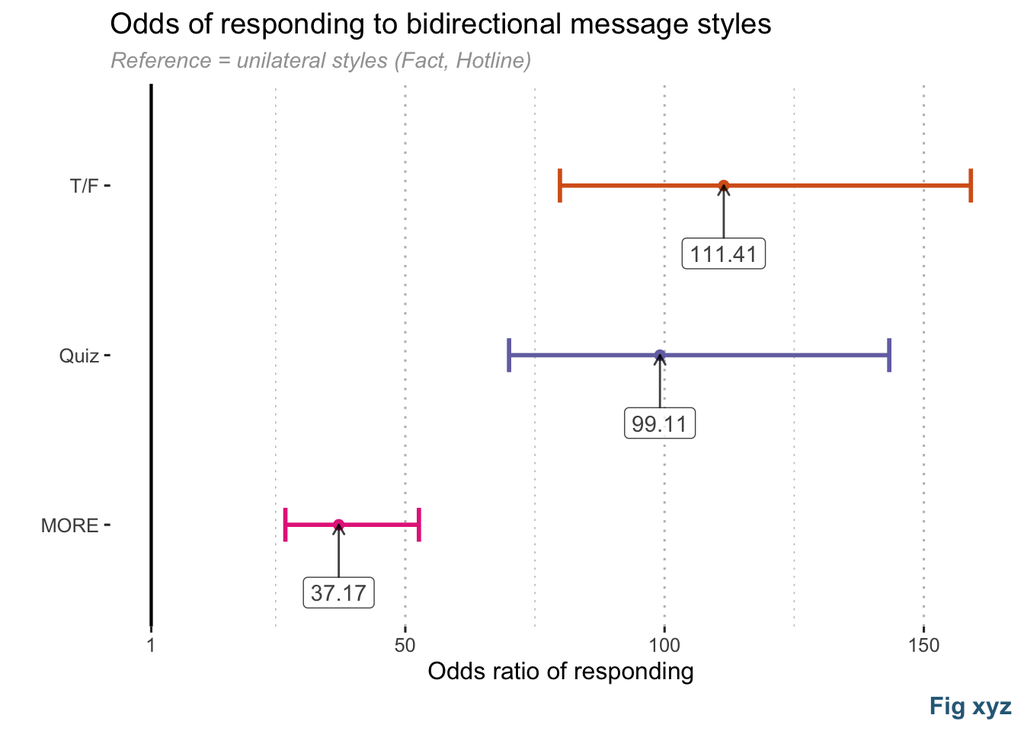

```r
x %>% filter(VarCat!="") %>%
  filter(VarCat=="Style") %>%
  filter(term!="Hotline") %>% # only look at bidirectional messages

  ggplot(aes(x=term, y=expB, color=term)) +
  geom_hline(yintercept = 1, linetype = 1, alpha=1, size=0.75) +
  geom_point(size=2) +
  geom_errorbar(aes(ymin=expLL, ymax=expUL), width=.2, size=1) +
  geom_label_repel(aes(label=round(expB,2)), nudge_x=-0.4, alpha=0.75,
                   arrow = arrow(length = unit(0.02, "npc")), color="black") +


  scale_color_manual(values=color_guide) +
  scale_y_continuous(breaks=c(1,50,100, 150), minor_breaks = c(25,75,125)) +
  coord_flip() + guides(color=F) + theme_pubclean(flip=T) +
  theme(panel.grid.minor.x = element_line(linetype = "dotted",
                                          color = "grey"),
        plot.caption       = element_text(face="bold", color="#2d6987", size=rel(1)),
        plot.subtitle      = element_text(face="italic", color="#A1A1A1", size=rel(0.9))) +
  labs(x="", y="Odds ratio of responding", title="Odds of responding to bidirectional message styles",
       subtitle='Reference = unilateral styles (Fact, Hotline)', caption = 'Fig xyz')
```

## Continious

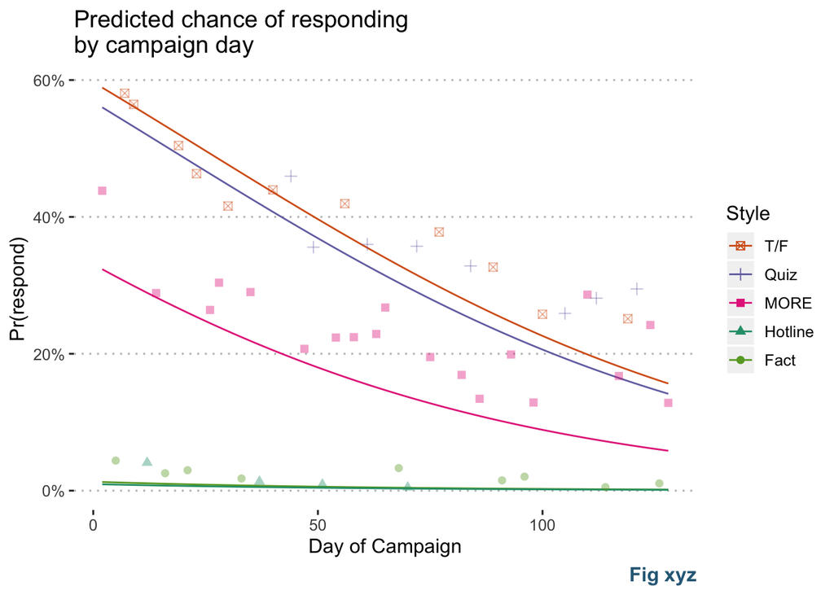

```r
df <- HRTC %>%
  filter(userResponses>0) %>%
  # mutate(Type = ifelse(campg.day==26, "Hotline", Type)) %>% # Change the one hotline question from MORE to hotline
  mutate(Category = as.factor(Category)) %>%
  mutate(Replied = ifelse(Replied==1, "Yes", "No")) %>%
  mutate(Replied = factor(Replied, levels=c("No","Yes")))

# Use same model as above, but use `campg.day` instead of `campg.num`
mod <- glm(Replied ~ Type + grade + race + gender + userResponses + campg.day,
           data=df, family=binomial(link = "logit"))


## make comparison data....
jtoolResults <- jtools::make_predictions(mod, pred = "campg.day", return.orig.data=T)
predictions <- jtoolResults$predictions
actualData <- jtoolResults$data %>%
  count(campg.day, Type, Replied) %>%
  spread(Replied, n) %>%
  mutate(
    n = Yes + No,
    PercentRespond = Yes/n
  ) %>% left_join(select(count(HRTC, Type, Message, campg.day, campg.num, mid), campg.day, Message))
rm(jtoolResults, predictions)


bind_rows(
  make_predictions(mod, pred = "campg.day", at=list("Type"="MORE")),
  make_predictions(mod, pred = "campg.day", at=list("Type"="Quiz")),
  make_predictions(mod, pred = "campg.day", at=list("Type"="Hotline")),
  make_predictions(mod, pred = "campg.day", at=list("Type"="T/F")),
  make_predictions(mod, pred = "campg.day", at=list("Type"="Fact"))
) %>%

  ggplot(aes(x=campg.day, y=Replied)) +
  # geom_ribbon(aes(ymin=ymin, ymax=ymax, fill=Type), alpha=0.15) +
  geom_line(aes(color=Type)) +
  scale_fill_manual(values=color_guide, guide=F) +
  geom_point(aes(x=campg.day, y=PercentRespond, color=Type, shape=Type),
             size=2, data=actualData, alpha=0.4) +
  scale_color_manual(values=color_guide, name="Style") +
  scale_shape_discrete(name="Style") +
  guides(
    colour = guide_legend(override.aes = list(alpha = 1), reverse=T),
    shape = guide_legend(reverse=T)) +
  theme_pubclean() +
  theme(
    legend.position= "right",
    plot.subtitle  = element_text(face="italic", color="#A1A1A1", size=rel(0.9)),
    plot.caption   = element_text(face="bold", color="#2d6987", size=rel(1))
  ) +
  labs(x="Day of Campaign", y="Pr(respond)", caption = "Fig xyz",
       title="Predicted chance of responding\nby campaign day") +
  scale_y_continuous(labels=percent)
```

```r
rm(actualData)
```

# Survival

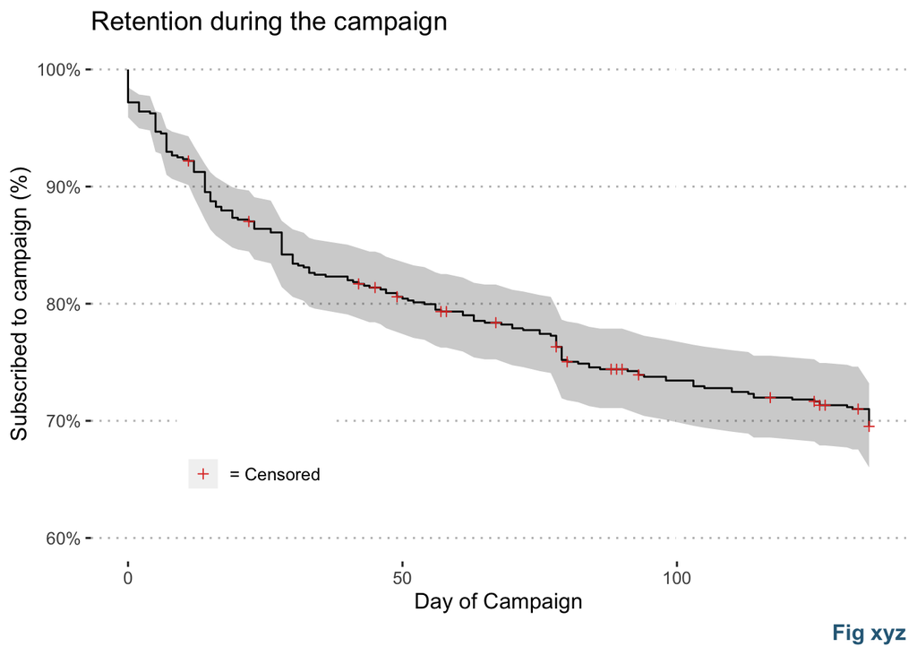

```r
survObj <- Surv(time=users$SurvEnd2, event=users$Censor)
SurvPlot <- survfit(survObj ~ 1, data = users) %>%
  ggsurv(size.est=1, size.ci=0.5,cens.size=3,
         lty.ci = 1 # linetype: was 5
    )
# SurvPlot  ## Plot the GGally plot

# Make your own plot
dat <- SurvPlot$data
dat.cens <- subset(dat, cens != 0)
dat %>%
  ggplot(aes(x=time, y=surv)) +
  geom_ribbon(aes(ymin=low, ymax=up), alpha=0.25) +
  geom_step() +
  geom_point(data=dat.cens, aes(y = surv, color="= Censored"),
      shape=3, size=1.5) +
  # geom_rug(data=count(HRTC, campg.day, Type), sides="b",
  #        aes(x=campg.day, y=0, color=Type), size=1) +

  theme_pubclean() +
  # theme(legend.position=c(0.5,0.1), legend.direction="horizontal") +
   theme(
    legend.position= c(0.2,0.2),
    plot.subtitle  = element_text(face="italic", color="#A1A1A1", size=rel(0.9)),
    plot.caption   = element_text(face="bold", color="#2d6987", size=rel(1))
  ) +
  scale_y_continuous(labels = scales::percent, limits=c(0.6,1)) +
  scale_color_manual(values=c("#df382c"), name="") +
  labs(x="Day of Campaign", y="Subscribed to campaign (%)", caption = "Fig xyz",
       title = "Retention during the campaign")
```

```r
# # Autoplot
# survfit(survObj ~ 1, data = users) %>%
#   ggsurvplot(data = users)
rm(SurvPlot, dat, dat.cens, survObj)
```

# Demographics

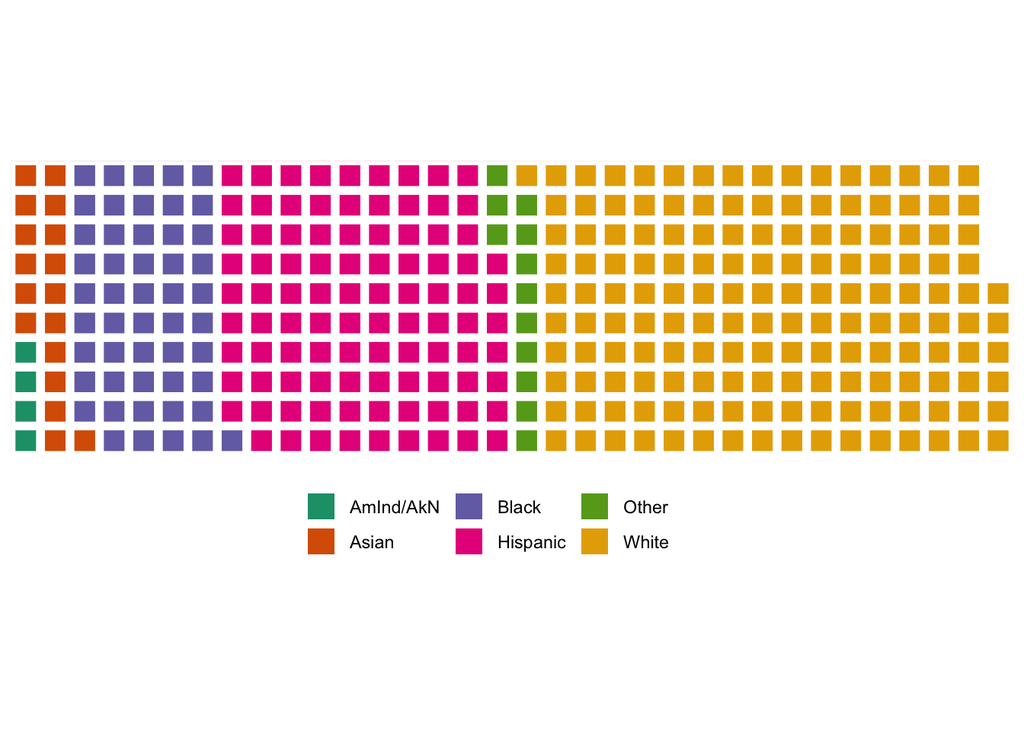

```r
Demographic <- "race" # gender, grade, race
df <- semi_join(users, select(HRTC, userID)) %>%
  count(!!sym(Demographic)) %>%
  filter(!is.na(!!sym(Demographic)))

numFactors <- dim(count(df, !!sym(Demographic)))[1]
if(Demographic=="gender") pal <- suppressWarnings(RColorBrewer::brewer.pal(numFactors, "Set1"))
if(Demographic=="grade") pal <- suppressWarnings(RColorBrewer::brewer.pal(numFactors, "Spectral"))
if(Demographic=="race") pal <- suppressWarnings(RColorBrewer::brewer.pal(numFactors, "Dark2"))


df %>% waffle(legend_pos="bottom", flip=F, colors=pal)
```

```r
rm(Demographic, numFactors, pal)
```

# Response to message style

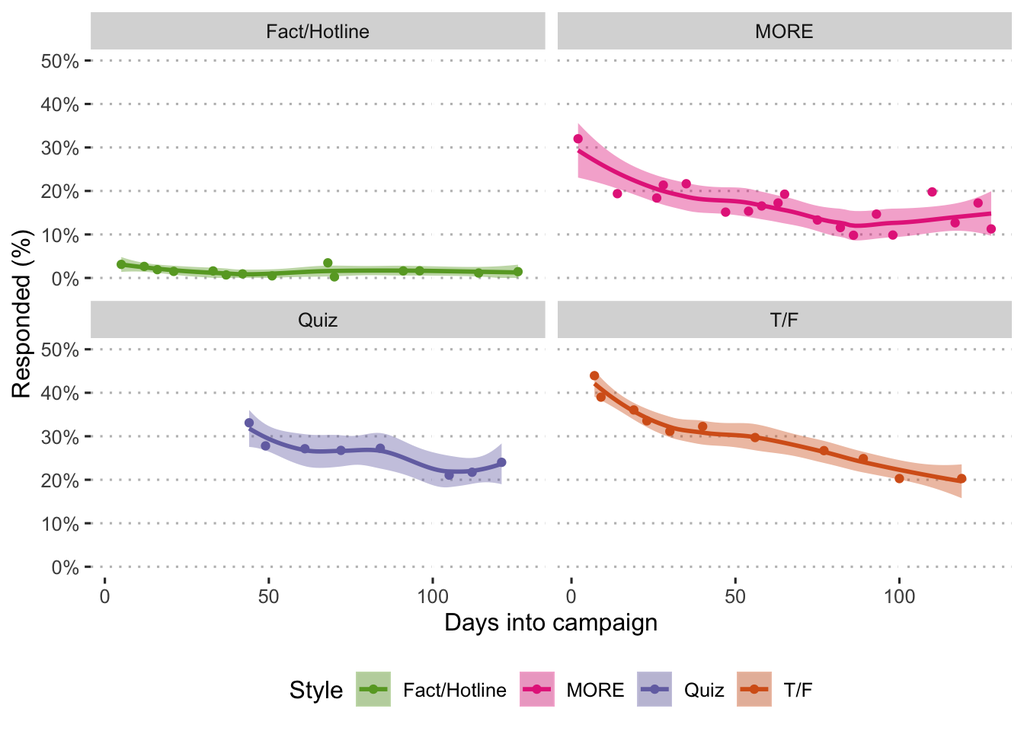

```r
actual <- HRTC %>%
  mutate(
    Type = recode(Type, "Fact"="Fact/Hotline"),
    Type = recode(Type, "Hotline"="Fact/Hotline")
    ) %>%
  mutate(Replied = as.character(Replied)) %>%
  mutate(Type = ifelse(campg.day==26, "MORE", Type)) %>%
  mutate(
    Replied = recode(Replied, "0"="No"),
    Replied = recode(Replied, "1"="Yes")
    ) %>%
  count(campg.day, Type, Replied, mid) %>%
  spread(Replied, n) %>%
  group_by(Type, campg.day, mid) %>%
  summarise(Yes = sum(Yes, na.rm=T), No=sum(No, na.rm=T)) %>%
  mutate(
    `Reply %` = Yes/(Yes+No),
    n         = Yes + No
  )

actual %>%
  ggplot(aes(x=campg.day, y=`Reply %`, color=Type)) +
  # geom_col(aes(fill=Type)) +
  # geom_step() +
  geom_point() + geom_smooth(aes(fill=Type)) +
  facet_wrap("Type") +
  theme_pubclean() +
  theme(legend.position="bottom") +
  scale_y_continuous(labels=percent, limits = c(0,0.5), oob=scales::squish) +
  scale_color_manual(values=color_guide, name="Style") +
  scale_fill_manual(values=color_guide, name="Style") +

  labs(x="Days into campaign", y="Responded (%)")
```

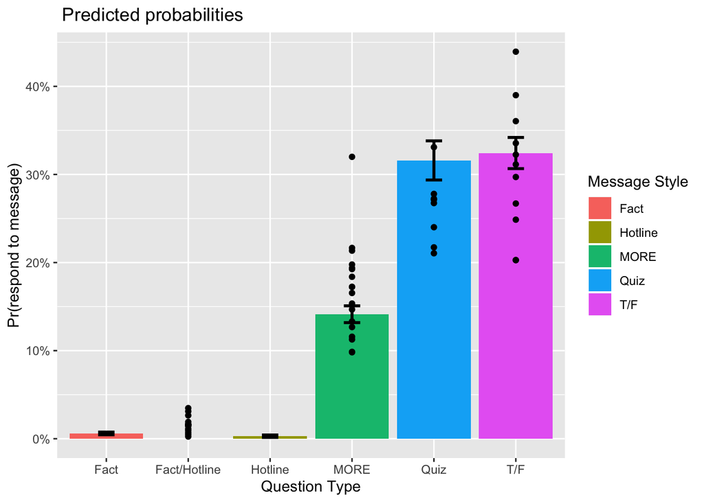

```r
dfModel <- HRTC %>%
  filter(userResponses>0) %>%
  mutate(Dummy = as.factor(zipcode)) %>%
  mutate(userID = as.factor(userID)) %>%
  mutate(Category = as.factor(Category)) %>%
  mutate(Replied = ifelse(Replied==1, "Yes", "No")) %>%
  mutate(Replied = factor(Replied, levels=c("No","Yes")))

mod <- glm(Replied ~ Type + userResponses + campg.num,
           data=dfModel, family=binomial(link = "logit"))

newDf <- data.frame(
  userResponses = rep(mean(dfModel$userResponses),5),
  campg.num     = rep(mean(dfModel$campg.num),5),
  Type          = unique(dfModel$Type)
)

cbind(newDf, predict(mod, newdata=newDf, type="response", se.fit=TRUE)) %>%
  rename(prob=fit, se.prob=se.fit) %>%
  mutate(
    ll = prob - 1.96*se.prob,
    ul = prob + 1.96*se.prob,
  ) %>%
  ggplot(aes(x=Type, y = prob)) +
  geom_col(aes(fill=Type)) +
  geom_errorbar(aes(ymin = ll, ymax = ul), width = 0.2, lty=1, lwd=1) +
  # geom_point(shape=18, size=3, fill="black") +
  geom_point(aes(x=Type, y=`Reply %`), data=actual) +
  scale_color_discrete(name="Message Style") +
  scale_fill_discrete(name="Message Style") +
  scale_y_continuous(labels=percent) +
  labs(title= " Predicted probabilities", x="Question Type", y="Pr(respond to message)")
```

```r
rm(dfModel, mod, newDf)
rm(actual)
```

**R version 3.3.2 (2016-10-31)**

**Platform:** x86_64-apple-darwin13.4.0 (64-bit)

**locale:** en_US.UTF-8||en_US.UTF-8||en_US.UTF-8||C||en_US.UTF-8||en_US.UTF-8

**attached base packages:** *stats*, *graphics*, *grDevices*, *utils*, *datasets*, *methods* and *base*

**other attached packages:** *bindrcpp(v.0.2.2)*, *jtools(v.2.0.0)*, *GGally(v.1.4.0)*, *waffle(v.0.9.1)*, *ggrepel(v.0.6.6)*, *pander(v.0.6.3)*, *survMisc(v.0.5.5)*, *survminer(v.0.4.3)*, *ggpubr(v.0.2)*, *magrittr(v.1.5)*, *survival(v.2.40-1)*, *lme4(v.1.1-19)*, *Matrix(v.1.2-7.1)*, *stargazer(v.5.2.2)*, *scales(v.0.5.0)*, *knitr(v.1.18)*, *lubridate(v.1.7.1)*, *forcats(v.0.2.0)*, *stringr(v.1.2.0)*, *dplyr(v.0.7.8)*, *purrr(v.0.2.4)*, *readr(v.1.1.1)*, *tidyr(v.0.7.2)*, *tibble(v.1.4.2)*, *ggplot2(v.3.1.0.9000)*, *tidyverse(v.1.2.1)* and *MASS(v.7.3-45)*

**loaded via a namespace (and not attached):** *httr(v.1.3.1)*, *jsonlite(v.1.6)*, *splines(v.3.3.2)*, *modelr(v.0.1.1)*, *assertthat(v.0.2.0)*, *cellranger(v.1.1.0)*, *yaml(v.2.2.0)*, *Rttf2pt1(v.1.3.7)*, *pillar(v.1.3.1)*, *backports(v.1.1.2)*, *lattice(v.0.20-34)*, *glue(v.1.2.0)*, *extrafontdb(v.1.0)*, *digest(v.0.6.13)*, *RColorBrewer(v.1.1-2)*, *rvest(v.0.3.2)*, *minqa(v.1.2.4)*, *colorspace(v.1.3-2)*, *cmprsk(v.2.2-7)*, *htmltools(v.0.3.6)*, *plyr(v.1.8.4)*, *pkgconfig(v.2.0.2)*, *broom(v.0.5.1.9000)*, *haven(v.1.1.0)*, *xtable(v.1.8-2)*, *km.ci(v.0.5-2)*, *KMsurv(v.0.1-5)*, *generics(v.0.0.2)*, *withr(v.2.1.2)*, *lazyeval(v.0.2.1)*, *cli(v.1.0.1)*, *crayon(v.1.3.4)*, *readxl(v.1.0.0)*, *evaluate(v.0.10)*, *nlme(v.3.1-128)*, *xml2(v.1.1.1)*, *tools(v.3.3.2)*, *data.table(v.1.10.4-3)*, *hms(v.0.4.0)*, *munsell(v.0.5.0)*, *rlang(v.0.3.0.1)*, *grid(v.3.3.2)*, *nloptr(v.1.2.1)*, *rstudioapi(v.0.9.0)*, *labeling(v.0.3)*, *rmarkdown(v.1.8)*, *gtable(v.0.2.0)*, *reshape(v.0.8.8)*, *curl(v.3.1)*, *R6(v.2.2.2)*, *gridExtra(v.2.2.1)*, *zoo(v.1.8-4)*, *extrafont(v.0.17)*, *bindr(v.0.1.1)*, *rprojroot(v.1.3-2)*, *stringi(v.1.1.6)*, *Rcpp(v.1.0.0)* and *tidyselect(v.0.2.3)*